# Flujo de trabajo en Estadística

Pedro Montenegro

28/8/2019

La metodología que se usa diariamente es la CRISP, se trabaja principalmente en el lenguaje R y bases de datos Oracle, SQL y git-tfs para windows donde se maneja el control de versión.

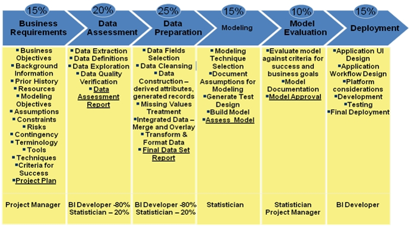

Diagrama

[interactive chart not shown]

De inicio, es claro que nuestra forma de trabajo posee 6 etapas, pero no representa un proceso lineal, es decir, una vez que finaliza una etapa puede haber dependencia con la siguiente fase o se puede adelantar etapas en cierto punto del proyecto y existen diversos actores, un grupo de trabajo multidisciplinario.

# Preguntas

*Transparencia*: En mi equipo de trabajo lo utilizamos para que todos los colaboradores que programamos podamos revisar los projectos y los cambios que hemos realizado, además, es una herramienta que sirve para que nuestro jefe lo revise.

*Capacidad de mantenerlo*: Sí, porque todo el código se utiliza en repositorios y se puede devolver a traves del tfs.

*Modularidad*: Todos los componentes del trabajo están separado a través de la metodología CRISP.

*Portabilidad*: Tener en un servicio web en tfs nos permite levantar los proyectos de forma fácil.

*Reproducibilidad y eficiencia*: Al mantener de manera virtual puedo reproducir todo el processo muy fácil desde bases de datos hasta replicar el código, el único problema es el control de versiones de los paquetes.